# Introduction to the ContourFunctions R package

Collin Erickson

2024-09-09

The ContourFunctions R package provides functions that make it easier to make contour plots. The function `cf` is a quick function that can take in grid data, a function, or any data, and give a contour plot showing the function or data. By default, plots are made using base graphics, but they can also be done using ggplot2.

## `cf_grid`

`cf_grid` creates a contour plot from a grid of points.

Below `a` and `b` create a grid of points at which `r` is calculated. `cf_grid` is used to create the contour plot. Note that the only indication of the relationship between the colors and the `r` values is in the title of plot, which says that the darkest blue point is the minimum of -0.613, and the darkest pink point is the maximum of 1. (Note that this is not a good representation of the surface because there aren’t enough points in the grid, the contours are actually concentric circles as shown below.)

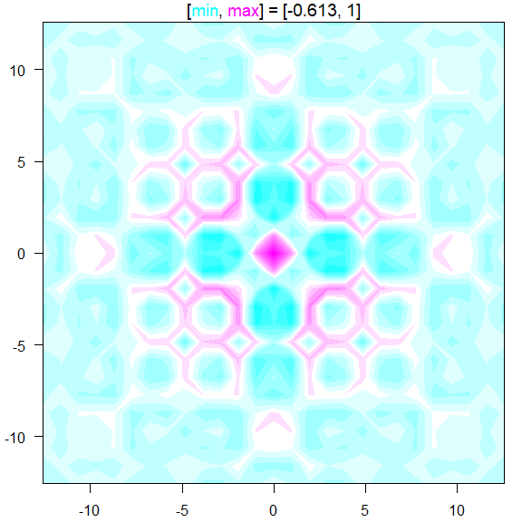

```r
library(ContourFunctions)
a <- b <- seq(-4*pi, 4*pi, len = 27)
r <- sqrt(outer(a^2, b^2, "+"))
cf_grid(a, b, cos(r^2)*exp(-r/(2*pi)))
```

To add a bar that shows how the colors relate to the output, simply set `bar=TRUE`, as shown below.

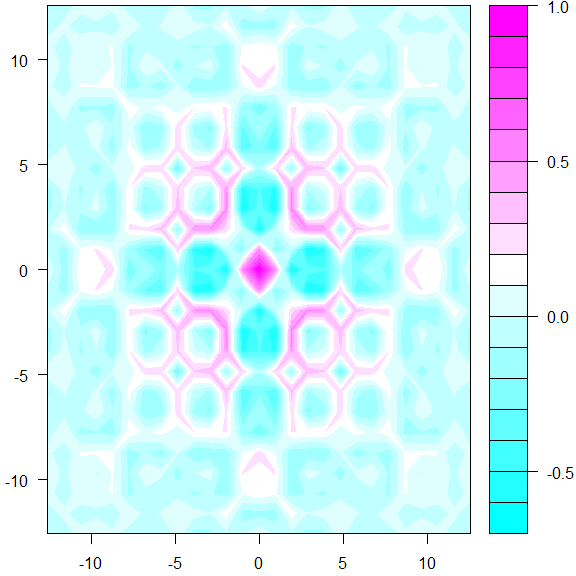

```r
cf_grid(a, b, cos(r^2)*exp(-r/(2*pi)), bar=TRUE)
```

Other parameters specifying details of the plot can be passed as well, see the documentation for those options.

## `cf_func`

For the above we had to create the grid of points and give it in to `cf_grid`. To make this easier, `cf_func` allows you to simply pass in a function. It will then evaluate the function at a grid of points and pass these to `cf_grid` to make the contour plot.

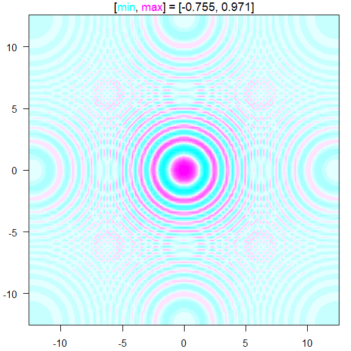

```r
f1 <- function(r) cos(r[1]^2 + r[2]^2)*exp(-sqrt(r[1]^2 + r[2]^2)/(2*pi))
cf_func(f1, xlim = c(-4*pi, 4*pi), ylim = c(-4*pi, 4*pi))
```

If you give a function that can more efficient evaluate a bunch of points at a time, instead of one at a time, use the `batchmax` to have it pass points as a matrix to the given function.

The argument `n` controls how many points along each dimension are used. We see below that if we go back to `n=27`, then we get the same plot as above.

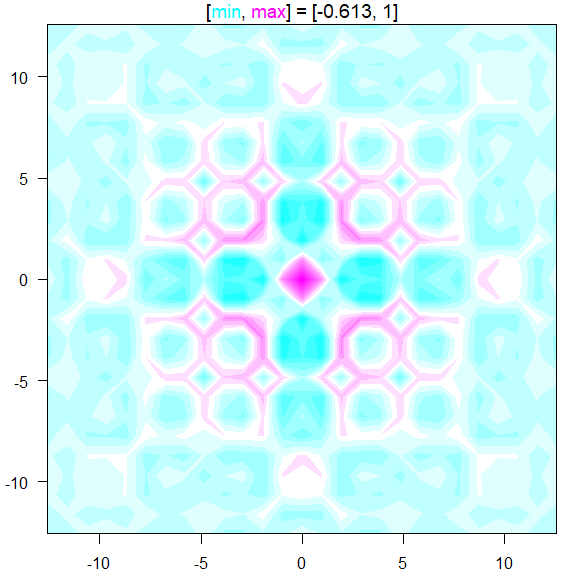

```r
cf_func(f1, xlim = c(-4*pi, 4*pi), ylim = c(-4*pi, 4*pi), n=27)
```

## `cf_data`

Often one has data and wants to get an idea of what the surface looks like that fits the data. The `cf_data` allows the user to pass in the data to get such a plot. A Gaussian process model is fit to the data, by default using the R package laGP to do so. The model is then used to make predictions at the grid of points to make the contour plot. The model prediction function is passed to `cf_func` to create the contour plot. Note that this relies heavily on the model being somewhat accurate, and may not truly represent the data if the model is a poor fit.

Below a random sample of 20 points are taken from a function (a Gaussian peak centered at (0.5, 0.5)), and `cf_data` is used to plot the data. The black dots show the data points used to create the model.

```r
set.seed(0)
x <- runif(20)
y <- runif(20)
z <- exp(-(x-.5)^2-5*(y-.5)^2)# + rnorm(20,0,.05)
# cf_data(x,y,z)
cf_data(x,y,z, bar=T)
```

```
## Fitting with laGP since n <= 200 (or locfit not available)
```

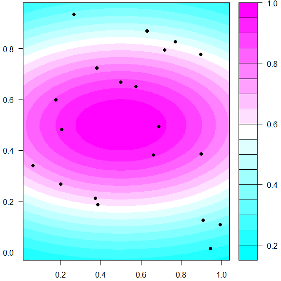

## `afterplotfunc`

The contour plots are created using the `split.screen` function. This causes the plot to not add additional items, such as points or lines, after making the plot. The plot below shows how when trying to add a point to the plot using `points`, a point that should be placed at the center ends up in the bottom right corner.

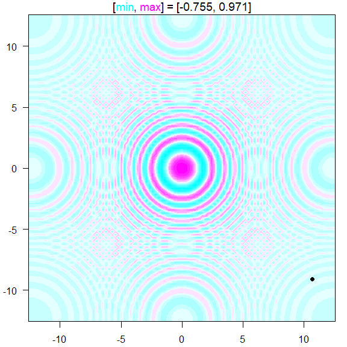

```r
cf_func(f1, xlim = c(-4*pi, 4*pi), ylim = c(-4*pi, 4*pi))
points(c(0,0), pch=19)
```

If you just want to add points, you can use the parameter `pts` to do so. Below we see that the point ends up correctly in the center of the plot.

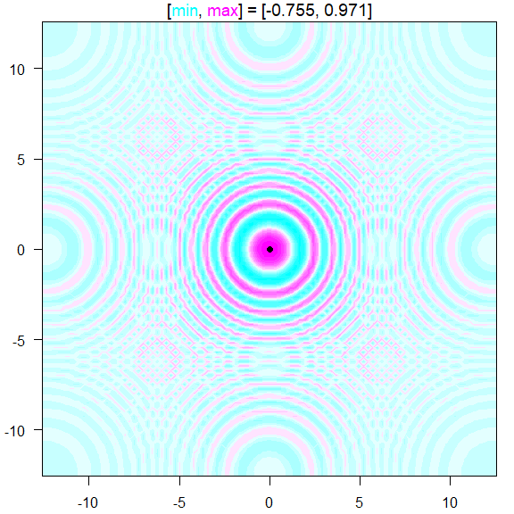

```r
cf_func(f1, xlim = c(-4*pi, 4*pi), ylim = c(-4*pi, 4*pi), pts=c(0,0))
```

Another option, that gives you more capability, is to use the parameter `afterplotfunc` to pass in a function that takes no arguments. After the plot is made this function will be called. You can put anything inside this function that you would normally do to a plot, including `points`, `text`, `legend`, and `abline`.

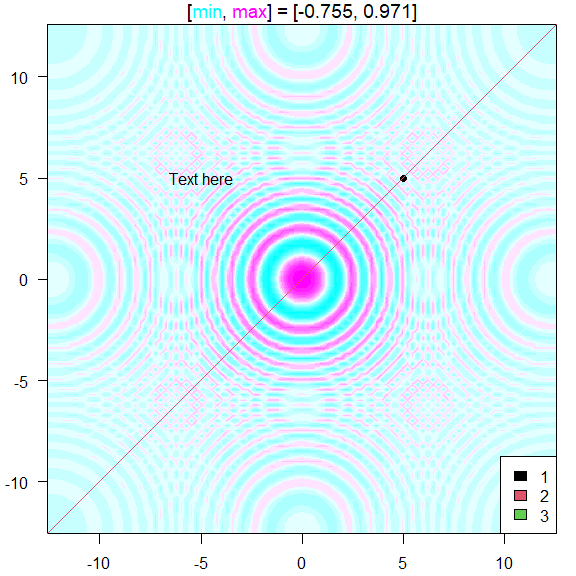

```r
cf_func(f1, xlim = c(-4*pi, 4*pi), ylim = c(-4*pi, 4*pi),
        afterplotfunc=function() {
          points(5, 5, pch=19)
          text(-5,5,"Text here")
          legend('bottomright', legend=c(1,2,3), fill=c(1,2,3))
          abline(a=0, b=1, col=2)
          }
        )
```

## `cf`

To make using the above `cf_func` and `cf_data` slightly easier, the same inputs can be passed to the function `cf`. It detects whether the first parameter is a function, in which case it passes everything to `cf_func` or numeric, in which case it passes everything to `cf_data`.

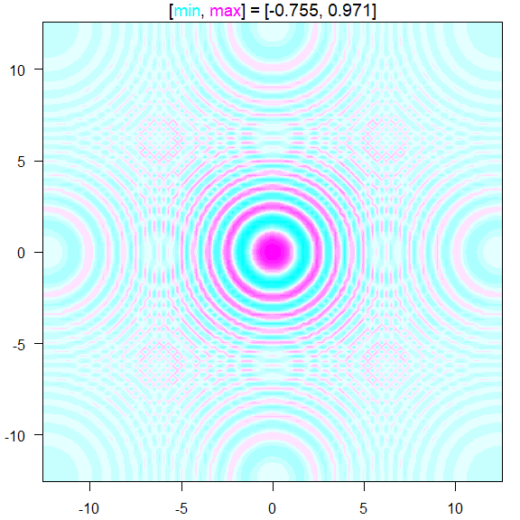

```r
cf(f1, xlim = c(-4*pi, 4*pi), ylim = c(-4*pi, 4*pi))
```

```r
cf(x,y,z, bar=T)
```

```
## Fitting with laGP since n <= 200 (or locfit not available)
```

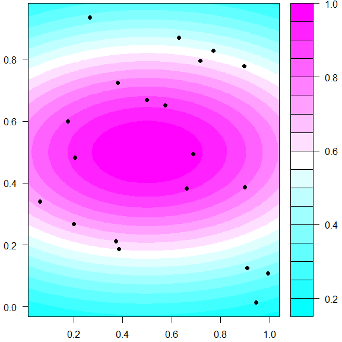

## `cf_highdim`

For higher dimensional functions, `cf_highdim` makes a contour plot of two-dimensional slices of the given function. The dimensions not being shown can be set to a default value or averaged out.

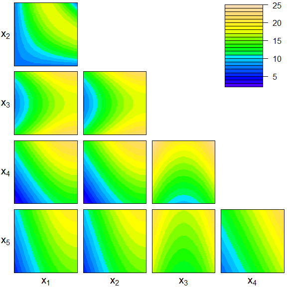

```r
friedman <- function(x) {
  10*sin(pi*x[1]*x[2]) + 20*(x[3]-.5)^2 + 10*x[4] + 5*x[5]
}
cf_highdim(friedman, 5, color.palette=topo.colors)
```

## `cf_4dim`

Functions with four input dimensions can be displayed using a grid of contour plots with the function `cf_4dim`. Two of the dimensions are shown on each plot, while the other two are set to a specific value for the given plot.

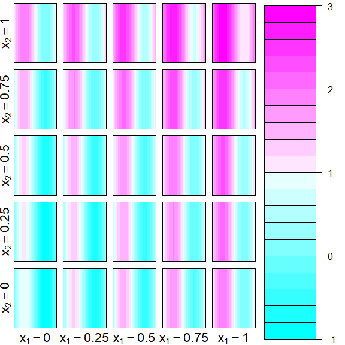

```r
cf_4dim(function(x) {x[1] + x[2]^2 + sin(2*pi*x[3])})
```

## Making plots with ggplot2

All of the above plots used R base graphics. Similar functions for `cf`, `cf_func`, `cf_data`, and `cf_grid` that use ggplot2 are also available as `gcf`, `gcf_func`, `gcf_data`, and `gcf_grid`

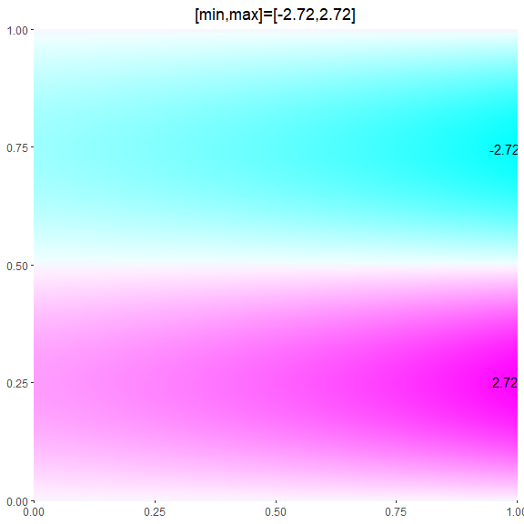

```r
f2 <- function(x) {exp(x[1]) * sin(2*pi*x[2])}
gcf(f2)
```

## Adding contour lines to plots

By default, the contour plots are made using filled colors. To add lines on top of the color fill, use `with_lines=TRUE`. To make a contour plot with only lines, use `lines_only=TRUE`.

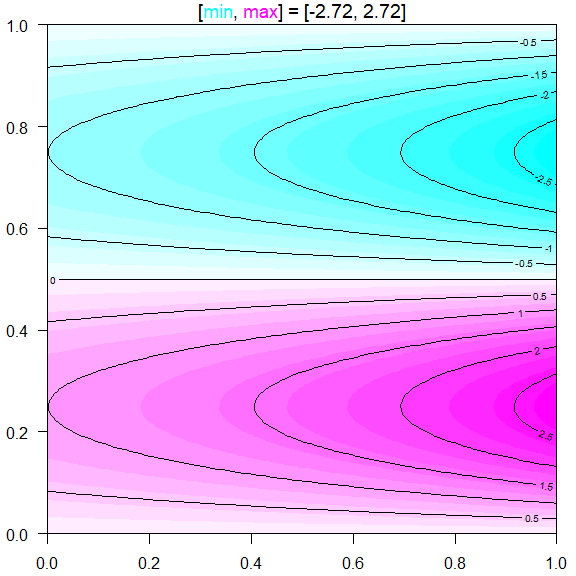

```r
cf(f2, with_lines=TRUE)
```

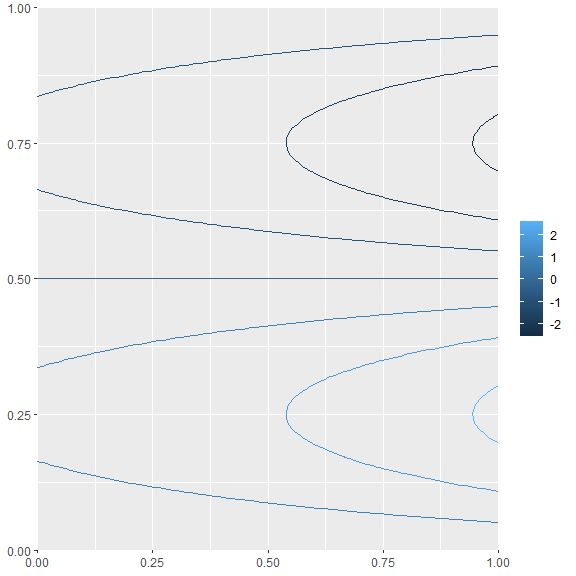

```r
gcf(f2, lines_only=TRUE, bar=T)
```